# TP53_survival_analysis

Zhuangzhuang Geng

2023-09-20

### load libraries

```r
suppressWarnings({
  library(tidyverse)
  library(survival)
  library(ggplot2)
  library(patchwork)
})
```

### set directories and source functions for plotting

```r
root_dir <- rprojroot::find_root(rprojroot::has_dir(".git"))
analyses_dir <- file.path(root_dir, "analyses", "survival-analysis")
input_dir <- file.path(analyses_dir, "input")
plots_dir <- file.path(analyses_dir, "plots")

## source this script for plotting
source(file.path(analyses_dir, "utils", "survival_models.R"))
```

### transfomr OS_days to OS_years

```r
HGG_survival <- read_tsv(file.path(input_dir, "HGG_survival_tp53.tsv"))

HGG_survival <- HGG_survival %>%
  mutate(OS_years = (OS_days / 365.25),
         binned_tp53 = replace_na(binned_tp53, "no tp53 score"),
         plot_mol_subtype = case_when(grepl("IHG", molecular_subtype) ~ "IHG",
                                      TRUE ~ molecular_subtype))
```

### plot the Kaplan–Meier survival curve on

### broad_mol, mol_subtype_without_tp53, gender, binned age, race and binned_tp53 score

```r
var <- c("reported_gender", "binned_age", "binned_tp53", "broad_mol", "mol_subtype_without_tp53", "race")

for(i in var){

  kap_OS <- survival_analysis(
  metadata = HGG_survival,
  ind_var = i,
  test = "kap.meier",
  metadata_sample_col = "sample_id",
  days_col = "OS_days",
  status_col = "OS_status")

  plot <- plotKM(model = kap_OS,
       variable = i,
       combined = FALSE,
       title = i)

  if(i == "race"){
    ggsave(file.path(plots_dir, paste0("KM_", i, ".pdf")), plot,
       width = 16, height = 6, units = "in",
       device = "pdf")
  }else{
    ggsave(file.path(plots_dir, paste0("KM_", i, ".pdf")), plot,
       width = 10, height = 6, units = "in",
       device = "pdf")
  }

}
```

### Add a new column `plot_mol_subtype` by combining all IHG subtypes as `IHG` from `molecular_subtype` column and

### manually set `HGG, H3 wildtype` and `[0,15]` as controls and

### plot forest plot with tp53_score, reported_gender, plot_mol_subtype, and binned_age

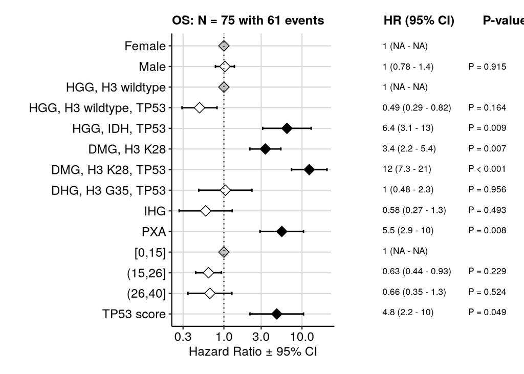

```r
HGG_survival <- HGG_survival %>%
  mutate(plot_mol_subtype = factor(plot_mol_subtype, levels = c("HGG, H3 wildtype", "HGG, H3 wildtype, TP53", "HGG, IDH", "HGG, IDH, TP53", "HGG, To be classified", "DMG, H3 K28", "DMG, H3 K28, TP53", "DHG, H3 G35, TP53", "IHG", "PXA")),
         binned_age = factor(binned_age, levels = c("[0,15]", "(15,26]", "(26,40]", "not reported")))

survival_cox <- fit_save_model(HGG_survival,
                                    terms = "tp53_score + reported_gender + plot_mol_subtype + binned_age",
                                    output_file = file.path(analyses_dir, "results", "tp53_score+reported_gender+mol_subtype+binned_age.RDS"),
                                    model_type = "multivariate")

model <- read_rds(file.path(analyses_dir, "results", "tp53_score+reported_gender+mol_subtype+binned_age.RDS"))

## manually change the coefficient name, may need to address this issue later in survival script
names(model$coefficients) <- gsub("tp53_score", "TP53 score", names(model$coefficients))

plotForest(model)
```

### save plot

```r
ggsave(file.path(plots_dir, "HR_molecular_subtype.pdf"), width = 10, height = 6)
```

### manually set `White` as controls and

### plot forest plot with tp53_score, reported_gender, race, and binned_age

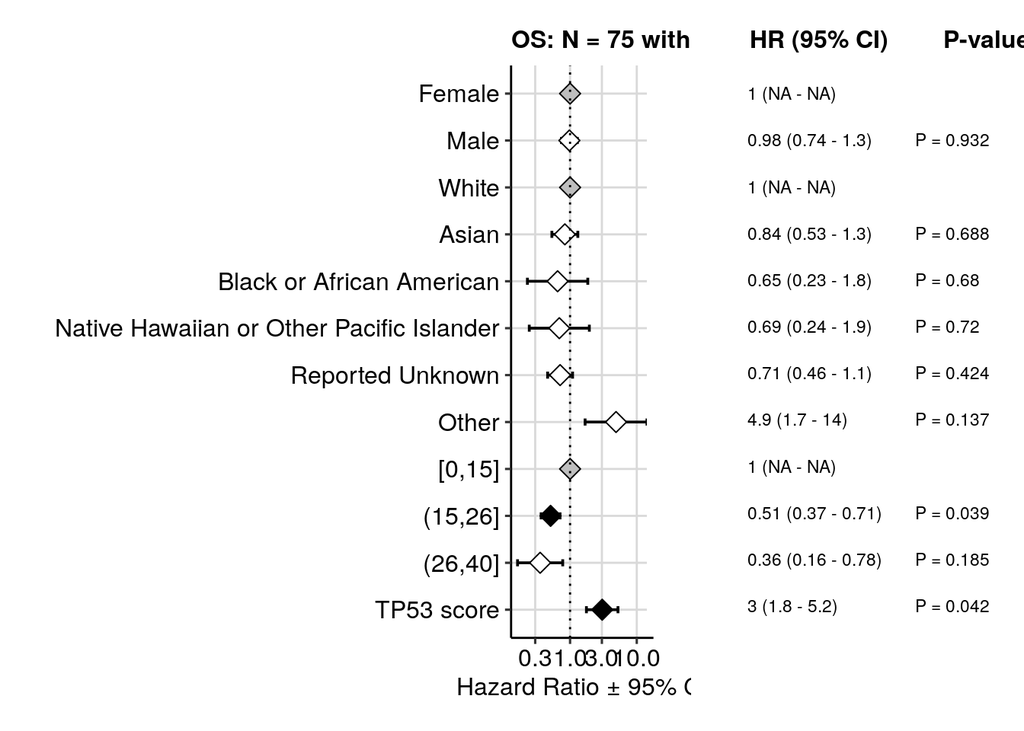

```r
HGG_survival <- HGG_survival %>%
  mutate(race = factor(race, levels = c("White", "Asian", "Black or African American", "Native Hawaiian or Other Pacific Islander", "Reported Unknown", "Other")))

survival_cox <- fit_save_model(HGG_survival,
                                    terms = "reported_gender + race + tp53_score + binned_age",
                                    output_file = file.path(analyses_dir, "results", "tp53_score+reported_gender+race+binned_age.RDS"),
                                    model_type = "multivariate")

model <- read_rds(file.path(analyses_dir, "results", "tp53_score+reported_gender+race+binned_age.RDS"))

## manually change the coefficient name, may need to address this issue later in survival script
names(model$coefficients) <- gsub("tp53_score", "TP53 score", names(model$coefficients))

plotForest(model)
```

### save plot

```r
ggsave(file.path(plots_dir, "HR_race.pdf"), width = 10, height = 6)
```

### calculate hazard ratio using tp53_score as continuous variat, reported gender, broad_mol and binned_age.

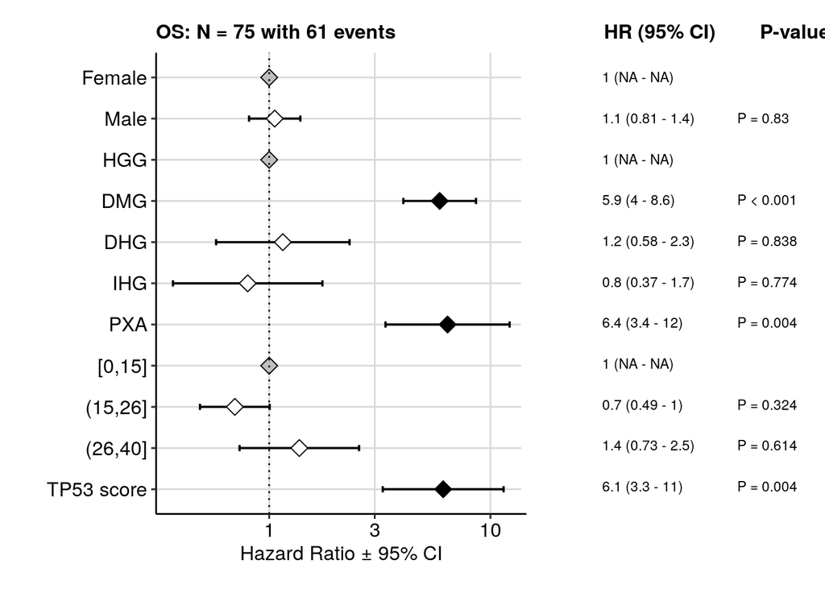

```r
HGG_survival <- HGG_survival %>%
  mutate(broad_mol = factor(broad_mol, levels = c("HGG", "DMG", "DHG",  "IHG", "PXA")))

survival_cox <- fit_save_model(HGG_survival,
                                    terms = "tp53_score + reported_gender + broad_mol + binned_age",
                                    output_file = file.path(analyses_dir, "results", "tp53_score+reported_gender+broad_mol+binned_age.RDS"),
                                    model_type = "multivariate")

model <- read_rds(file.path(analyses_dir, "results", "tp53_score+reported_gender+broad_mol+binned_age.RDS"))

## manually change the coefficient name, may need to address this issue later in survival script
names(model$coefficients) <- gsub("tp53_score", "TP53 score", names(model$coefficients))

plotForest(model)
```

### save the plot

```r
ggsave(file.path(plots_dir, "HR_broad_mol_subtype.pdf"), width = 10, height = 6)
```

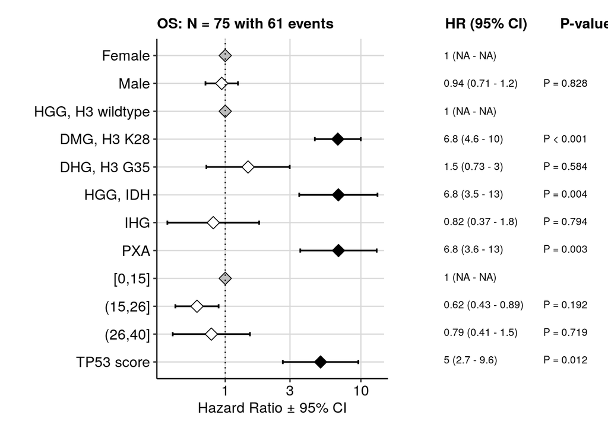

```r
HGG_survival <- HGG_survival %>%
  mutate(mol_subtype_without_tp53 = factor(mol_subtype_without_tp53,
                                           levels = c("HGG, H3 wildtype", "DMG, H3 K28", "DHG, H3 G35", "HGG, To be classified", "HGG, IDH", "IHG", "PXA")))

survival_cox <- fit_save_model(HGG_survival,
                                    terms = "tp53_score + reported_gender + mol_subtype_without_tp53 + binned_age",
                                    output_file = file.path(analyses_dir, "results", "tp53_score+reported_gender+mol_subtype_without_tp53+binned_age.RDS"),
                                    model_type = "multivariate")

model <- read_rds(file.path(analyses_dir, "results", "tp53_score+reported_gender+mol_subtype_without_tp53+binned_age.RDS"))

## manually change the coefficient name, may need to address this issue later in survival script
names(model$coefficients) <- gsub("tp53_score", "TP53 score", names(model$coefficients))

plotForest(model)
```

### save the plot

```r
ggsave(file.path(plots_dir, "HR_mol_subtype_without_tp53.pdf"), width = 10, height = 6)
```

### Take a look at two subtypes, `HGG, H3 WT` and `DMG, H3 K28`

```r
h3_wt <- HGG_survival %>%
  filter(grepl("HGG, H3 wildtype", molecular_subtype))

DMG <- HGG_survival %>%
  filter(grepl("DMG, H3 K28", molecular_subtype))
```

### calculate hazard ratio using tp53_score as continuous variat, reported gender, molecular_subtype and binned_age in `HGG, H3 WT` samples

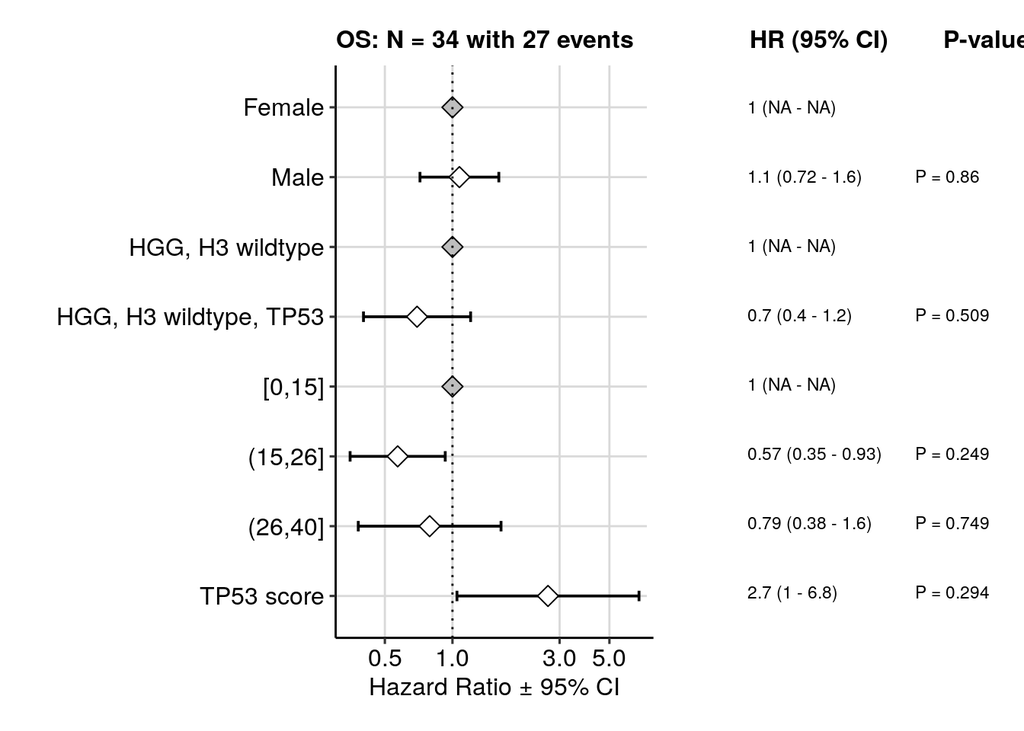

```r
tp53_survival_cox <- fit_save_model(h3_wt,
                                    terms = "tp53_score + reported_gender + molecular_subtype + binned_age",
                                    output_file = file.path(analyses_dir, "results", "HGG_H3WT_score+reported_gender+molecular_subtype+binned_age.RDS"),
                                    model_type = "multivariate")

HGG_H3WT_model <- read_rds(file.path(analyses_dir, "results", "HGG_H3WT_score+reported_gender+molecular_subtype+binned_age.RDS"))

## manually change the coefficient name, may need to address this issue later in survival script
names(HGG_H3WT_model$coefficients) <- gsub("tp53_score", "TP53 score", names(HGG_H3WT_model$coefficients))


plotForest(HGG_H3WT_model)
```

### save the plot

```r
ggsave(file.path(plots_dir, "HR_HGG_WT.pdf"), width = 10, height = 6)
```

### calculate hazard ratio using tp53_score as continuous variant, reported gender, molecular_subtype and binned_age in `DMG, H3 K28` samples

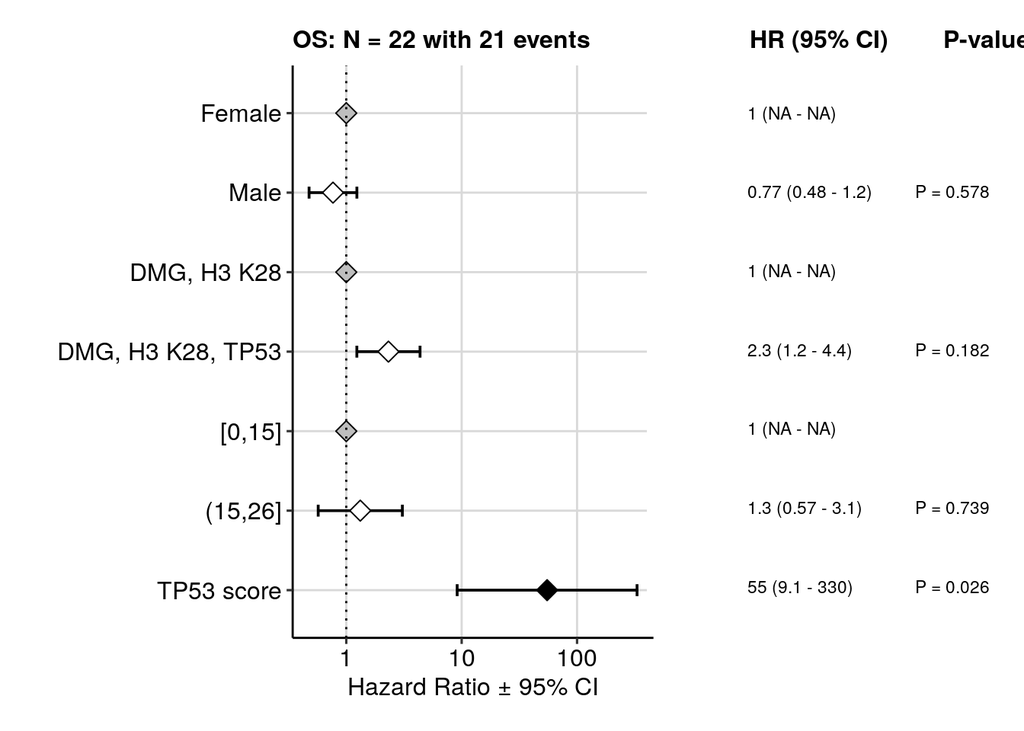

```r
tp53_survival_cox <- fit_save_model(DMG,
                                    terms = "tp53_score + reported_gender + molecular_subtype + binned_age",
                                    output_file = file.path(analyses_dir, "results", "DMG_score+reported_gender+molecular_subtype+binned_age.RDS"),
                                    model_type = "multivariate")

DMG_model <- read_rds(file.path(analyses_dir, "results", "DMG_score+reported_gender+molecular_subtype+binned_age.RDS"))

## manually change the coefficient name, may need to address this issue later in survival script
names(DMG_model$coefficients) <- c("TP53 score", names(DMG_model$coefficients)[2:6])


plotForest(DMG_model)
```

### save the plot

```r
ggsave(file.path(plots_dir, "HR_DMG.pdf"), width = 10, height = 6)
```

### testing the interaction between DMG and tp53 score

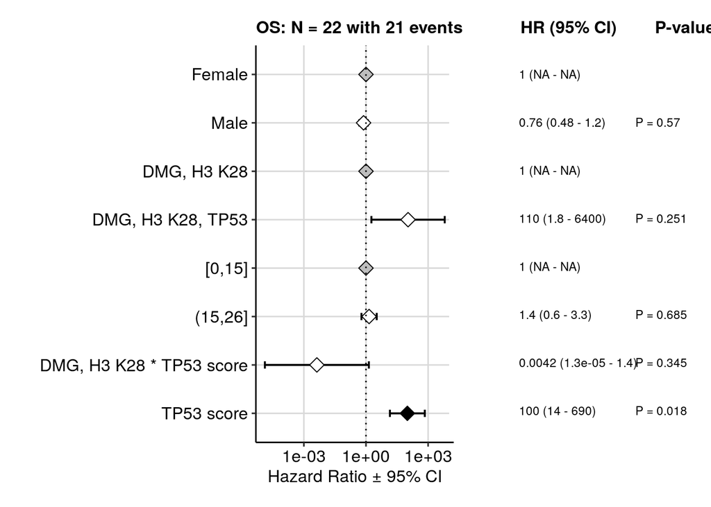

```r
tp53_survival_cox <- fit_save_model(DMG,
                                    terms = "reported_gender + molecular_subtype * tp53_score + binned_age",
                                    output_file = file.path(analyses_dir, "results", "DMG_score+reported_gender+molecular_subtype*tp53+binned_age.RDS"),
                                    model_type = "multivariate")

DMG_model <- read_rds(file.path(analyses_dir, "results", "DMG_score+reported_gender+molecular_subtype*tp53+binned_age.RDS"))

## manually change the coefficient name, may need to address this issue later in survival script
names(DMG_model$coefficients) <- c(names(DMG_model$coefficients)[1:2], "TP53 score", names(DMG_model$coefficients)[4:6], "DMG, H3 K28 * TP53 score")

plotForest(DMG_model)
```

### save the plot

```r
ggsave(file.path(plots_dir, "HR_DMG_tp53_interaction.pdf"), width = 8, height = 6)
```